# Homework 02

## Question 1: Training and test error under a fixed design

Consider a linear regression problem with $n=100$ observations and $q=20$ available covariates. Generate one matrix $\mathbf X_{\mathrm{all}}\in\mathbb R^{n\times q}$ whose entries are independent $\mathcal N(0,1)$ random variables, and then keep this realized matrix fixed. Let

$$\beta_k=0.4^{\sqrt{k}},
\qquad k=1,\ldots,q,$$

and define

$$\boldsymbol\mu=\mathbf X_{\mathrm{all}}\boldsymbol\beta.$$

Generate one training response and one independent test response from

$$\begin{aligned}
\mathbf y
&=\boldsymbol\mu+\boldsymbol\epsilon,\\
\mathbf y^*
&=\boldsymbol\mu+\boldsymbol\epsilon^*,
\end{aligned}$$

where

$$\boldsymbol\epsilon,\boldsymbol\epsilon^*
\overset{\mathrm{ind}}{\sim}
\mathcal N_n(\mathbf 0,\mathbf I_n).$$

Here $\mathbf I_n$ is the $n\times n$ identity matrix.

For $j=0,1,\ldots,q$, fit a linear model with an intercept and the first $j$ columns of $\mathbf X_{\mathrm{all}}$ using $\mathbf y$. If $\widehat{\boldsymbol\mu}_j$ is its fitted mean vector, define

$$\operatorname{MSE}_{\mathrm{train},j}
=\frac{1}{n}
\left\lVert
\mathbf y-\widehat{\boldsymbol\mu}_j
\right\rVert_2^2,$$

and

$$\operatorname{MSE}_{\mathrm{test},j}
=\frac{1}{n}
\left\lVert
\mathbf y^*-\widehat{\boldsymbol\mu}_j
\right\rVert_2^2.$$

Repeat this process independently 200 times, keeping $\mathbf X_{\mathrm{all}}$ fixed.

Use seed `43202` before generating $\mathbf X_{\mathrm{all}}$ and the response errors. R and Python use different random-number generators, so their exact numerical values need not agree.

1. For each $j$, calculate the average training and test MSE over the 200 simulation runs. Plot both curves against $j$. Verify numerically that training MSE does not increase as predictors are added in each simulation run.

**Show the starter code**

```r
set.seed(43202)

n <- 100
q <- 20
B <- 200

X <- matrix(rnorm(n * q), nrow = n)

beta <- 0.4^sqrt(1:q)
mu <- as.vector(X %*% beta)

train_mse <- matrix(0, B, q + 1)
test_mse <- matrix(0, B, q + 1)

for (b in 1:B) {

  y <- mu + rnorm(n)
  y_test <- mu + rnorm(n)

  for (j in 0:q) {

    if (j == 0) {
      fit <- lm(y ~ 1)
    } else {
      fit <- lm(y ~ X[, 1:j])
    }

    y_hat <- fitted(fit)

    train_mse[b, j + 1] <- mean((y - y_hat)^2)
    test_mse[b, j + 1] <- mean((y_test - y_hat)^2)
  }
}

avg_train <- colMeans(train_mse)
avg_test <- colMeans(test_mse)

data.frame(
  j = 0:q,
  Training_MSE = avg_train,
  Test_MSE = avg_test
)
```

```
    j Training_MSE Test_MSE
1   0    1.3146643 1.336716
2   1    1.1880807 1.227913
3   2    1.0986162 1.154570
4   3    1.0415172 1.114369
5   4    1.0104722 1.104631
6   5    0.9806254 1.097872
7   6    0.9623332 1.094007
8   7    0.9480987 1.099547
9   8    0.9327112 1.103380
10  9    0.9172755 1.109580
11 10    0.9061281 1.118629
12 11    0.8948077 1.125064
13 12    0.8846025 1.132503
14 13    0.8743504 1.138992
15 14    0.8624938 1.148920
16 15    0.8523713 1.159433
17 16    0.8409206 1.167473
18 17    0.8279270 1.178563
19 18    0.8166393 1.190993
20 19    0.8052183 1.205204
21 20    0.7948152 1.217043
```

**Show the starter code**

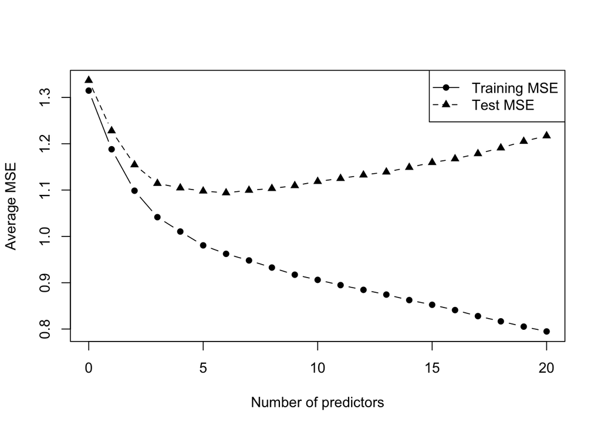

```r
plot(
  0:q, avg_train,
  type = "b",
  pch = 16,
  ylim = range(avg_train, avg_test),
  xlab = "Number of predictors",
  ylab = "Average MSE"
)

lines(
  0:q, avg_test,
  type = "b",
  pch = 17,
  lty = 2
)

legend(
  "topright",
  legend = c("Training MSE", "Test MSE"),
  pch = c(16, 17),
  lty = c(1, 2)
)
```

**Show the starter code**

```r
all(apply(
  train_mse,
  1,
  function(x) all(diff(x) <= 1e-10)
))
```

```
[1] TRUE
```

The training MSE does not increase when more predictors are added. The numerical check gives TRUE for all 200 simulations. This happens because the larger model contains all predictors from the smaller model.

2. For the model containing the first $j$ predictors, write

$$\mathbf X_j
=
[\mathbf 1,\mathbf x_1,\ldots,\mathbf x_j],
\qquad
\mathbf H_j
=
\mathbf X_j
(\mathbf X_j^{\mathsf T}\mathbf X_j)^{-1}
\mathbf X_j^{\mathsf T}.$$

Let $p_j=j+1$ be its fitted mean-parameter count, including the intercept. Define its **total squared approximation bias** as

$$B_j^2
=\left\lVert
(\mathbf I_n-\mathbf H_j)\boldsymbol\mu
\right\rVert_2^2.$$

Thus, $B_j^2/n$ is the mean squared approximation bias.

Calculate the two theoretical expectations

$$E\!\left(
\operatorname{MSE}_{\mathrm{train},j}
\mid \mathbf X_{\mathrm{all}}
\right)
=\frac{B_j^2}{n}+1-\frac{p_j}{n},$$

and

$$E\!\left(
\operatorname{MSE}_{\mathrm{test},j}
\mid \mathbf X_{\mathrm{all}}
\right)
=\frac{B_j^2}{n}+1+\frac{p_j}{n}.$$

Add these expectations to your plot and compare them with the simulation averages.

**Show the starter code**

```r
theory_train <- numeric(q + 1)
theory_test <- numeric(q + 1)

for (j in 0:q) {
  if (j == 0) {
    X_j <- matrix(1, nrow = n, ncol = 1)
  } else {
    X_j <- cbind(1, X[, 1:j])
  }

  H_j <- X_j %*% solve(t(X_j) %*% X_j) %*% t(X_j)

  B2 <- sum((mu - H_j %*% mu)^2)

  p_j <- j + 1

  theory_train[j + 1] <- B2 / n + 1 - p_j / n
  theory_test[j + 1] <- B2 / n + 1 + p_j / n
}
```

**Show the starter code**

```r
comparison <- data.frame(
  j = 0:q,
  Simulation_Train = avg_train,
  Theory_Train = theory_train,
  Simulation_Test = avg_test,
  Theory_Test = theory_test
)

round(comparison, 4)
```

```
    j Simulation_Train Theory_Train Simulation_Test Theory_Test
1   0           1.3147       1.2974          1.3367      1.3174
2   1           1.1881       1.1763          1.2279      1.2163
3   2           1.0986       1.0872          1.1546      1.1472
4   3           1.0415       1.0319          1.1144      1.1119
5   4           1.0105       1.0022          1.1046      1.1022
6   5           0.9806       0.9750          1.0979      1.0950
7   6           0.9623       0.9547          1.0940      1.0947
8   7           0.9481       0.9395          1.0995      1.0995
9   8           0.9327       0.9243          1.1034      1.1043
10  9           0.9173       0.9105          1.1096      1.1105
11 10           0.9061       0.8992          1.1186      1.1192
12 11           0.8948       0.8878          1.1251      1.1278
13 12           0.8846       0.8764          1.1325      1.1364
14 13           0.8744       0.8640          1.1390      1.1440
15 14           0.8625       0.8524          1.1489      1.1524
16 15           0.8524       0.8419          1.1594      1.1619
17 16           0.8409       0.8315          1.1675      1.1715
18 17           0.8279       0.8209          1.1786      1.1809
19 18           0.8166       0.8106          1.1910      1.1906
20 19           0.8052       0.8002          1.2052      1.2002
21 20           0.7948       0.7900          1.2170      1.2100
```

**Show the starter code**

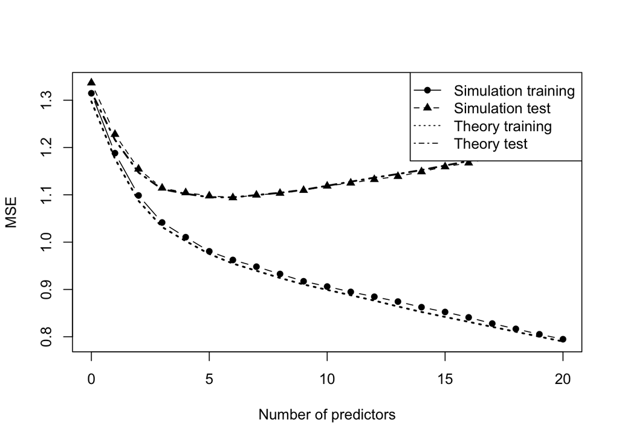

```r
all_mse <- c(avg_train, avg_test, theory_train, theory_test)

plot(
  0:q, avg_train,
  type = "b",
  pch = 16,
  ylim = range(all_mse),
  xlab = "Number of predictors",
  ylab = "MSE"
)

lines(0:q, avg_test, type = "b", pch = 17, lty = 2)
lines(0:q, theory_train, type = "l", lty = 3, lwd = 2)
lines(0:q, theory_test, type = "l", lty = 4, lwd = 2)

legend(
  "topright",
  legend = c(
    "Simulation training",
    "Simulation test",
    "Theory training",
    "Theory test"
  ),
  pch = c(16, 17, NA, NA),
  lty = c(1, 2, 3, 4)
)
```

The theoretical MSE curves are close to the average simulation curves. Small differences are caused by random simulation error. The training MSE decreases as more predictors are added. The test MSE first decreases because the approximation bias becomes smaller, but it can later increase because the model has more parameters and higher variance.

3. Add the test MSE curve from one simulation run to the plot. Explain why this single curve is less smooth than the average test MSE. Use the approximation-bias and estimation-variance terms in the expected test MSE to explain why training MSE cannot be used by itself to select the predictor count.

**Show the starter code**

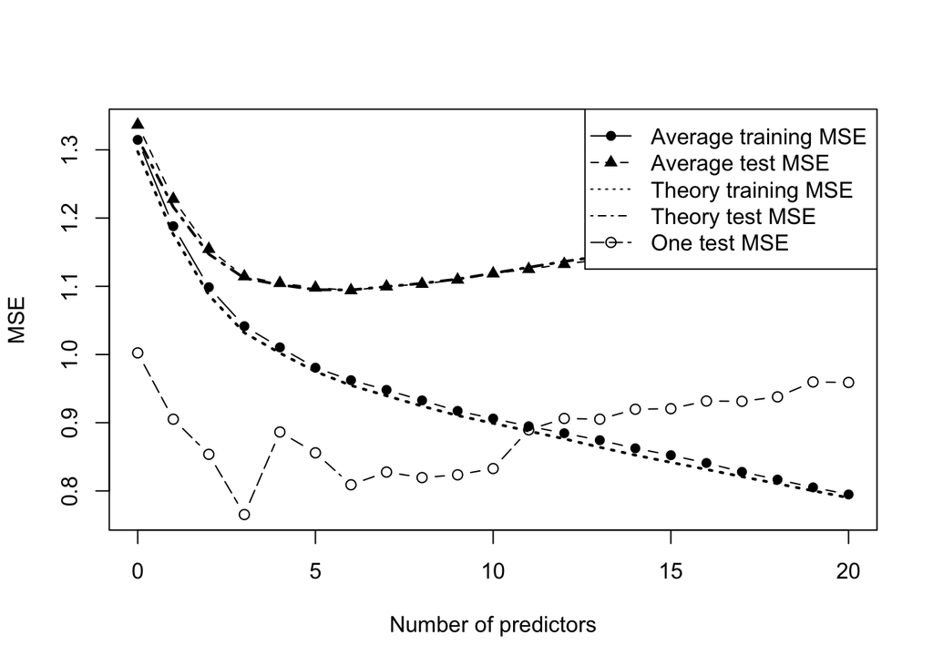

```r
one_test <- test_mse[1, ]

all_mse <- c(
  avg_train, avg_test,
  theory_train, theory_test,
  one_test
)

plot(
  0:q, avg_train,
  type = "b",
  pch = 16,
  ylim = range(all_mse),
  xlab = "Number of predictors",
  ylab = "MSE"
)

lines(0:q, avg_test, type = "b", pch = 17, lty = 2)

lines(0:q, theory_train, lty = 3, lwd = 2)

lines(0:q, theory_test, lty = 4, lwd = 2)

lines(0:q, one_test, type = "b", pch = 1, lty = 5)

legend(
  "topright",
  legend = c(
    "Average training MSE",
    "Average test MSE",
    "Theory training MSE",
    "Theory test MSE",
    "One test MSE"
  ),
  pch = c(16, 17, NA, NA, 1),
  lty = c(1, 2, 3, 4, 5)
)
```

The test MSE from one simulation is less smooth because it is affected by random noise. The average test MSE is smoother because it uses the results from 200 simulations. Adding more predictors reduces approximation bias, but it also increases estimation variance. Test MSE includes a penalty for using more parameters, while training MSE usually decreases when more parameters are added. Therefore, training MSE alone cannot be used to choose the best number of predictors. Test MSE or validation MSE should be used instead.

## Question 2: Prediction error at one target point

Let $n=100$, $q=6$, and $\sigma^2=1$. Construct the fixed covariate matrix $\mathbf X_{\mathrm{all}}\in\mathbb R^{n\times q}$ with entries

$$(\mathbf X_{\mathrm{all}})_{ik}
=\sqrt{2}\cos\left\{
\frac{\pi k(i-\tfrac12)}{n}
\right\},
\qquad
i=1,\ldots,n,
\quad
k=1,\ldots,q.$$

Its columns satisfy

$$\mathbf 1^{\mathsf T}\mathbf X_{\mathrm{all}}=\mathbf 0^{\mathsf T},
\qquad
\frac{1}{n}\mathbf X_{\mathrm{all}}^{\mathsf T}\mathbf X_{\mathrm{all}}=\mathbf I_q.$$

Here $\mathbf I_q$ is the $q\times q$ identity matrix.

The following code shows a direct construction of $\mathbf X_{\mathrm{all}}$.

**R**

**Show the starter code**

```r
n <- 100
q <- 6
X_all <- outer(
  1:n, 1:q,
  function(i, k) sqrt(2) * cos(pi * k * (i - 0.5) / n)
)
```

**Python**

**Show the starter code**

```python
import numpy as np

n, q = 100, 6
i = np.arange(1, n + 1)[:, None]
k = np.arange(1, q + 1)[None, :]
X_all = np.sqrt(2) * np.cos(np.pi * k * (i - 0.5) / n)
```

Keep $\mathbf X_{\mathrm{all}}$ fixed and generate one training response from

$$\mathbf y
=\mathbf X_{\mathrm{all}}\boldsymbol\beta+\boldsymbol\epsilon,
\qquad
\boldsymbol\beta
=(0.5,0.5,0.5,0.5,0.5,0.5)^{\mathsf T},$$

where

$$\boldsymbol\epsilon
\sim
\mathcal N_n(\mathbf 0,\mathbf I_n).$$

Here $\mathbf I_n$ is the $n\times n$ identity matrix.

For $j=0,\ldots,6$, fit a linear model with an intercept and the first $j$ predictors. Consider prediction of the mean response at

$$\mathbf x_0=(0,1,0,0,1,0)^{\mathsf T}.$$

Write

$$\mu_0=\mathbf x_0^{\mathsf T}\boldsymbol\beta,$$

and let $\widehat\mu_{0,j}$ be the prediction from the model containing the first $j$ predictors. Here $x_{0k}$ denotes the $k$th coordinate of $\mathbf x_0$. For this design,

$$E\!\left[
\left(\widehat\mu_{0,j}-\mu_0\right)^2
\mid \mathbf X_{\mathrm{all}}
\right]
=
\left(
\sum_{k=j+1}^{q}x_{0k}\beta_k
\right)^2
+\frac{\sigma^2}{n}
\left(
1+\sum_{k=1}^{j}x_{0k}^2
\right).$$

1. Calculate $\mu_0$ and the theoretical expected squared error for $j=0,\ldots,6$. Identify the values of $j$ where this error changes and where it remains unchanged.

**Show the starter code**

```r
n <- 100
q <- 6
sigma2 <- 1

beta <- rep(0.5, q)
x0 <- c(0, 1, 0, 0, 1, 0)

mu0 <- sum(x0 * beta)

theory_error <- numeric(q + 1)

for (j in 0:q) {

  if (j == q) {
    bias <- 0
  } else {
    bias <- sum(x0[(j + 1):q] * beta[(j + 1):q])
  }

  if (j == 0) {
    variance <- sigma2 / n
  } else {
    variance <- sigma2 / n * (1 + sum(x0[1:j]^2))
  }

  theory_error[j + 1] <- bias^2 + variance
}

mu0
```

```
[1] 1
```

**Show the starter code**

```r
data.frame(
  j = 0:q,
  Theoretical_Error = theory_error
)
```

```
  j Theoretical_Error
1 0              1.01
2 1              1.01
3 2              0.27
4 3              0.27
5 4              0.27
6 5              0.03
7 6              0.03
```

The mean response at the target point is 1. The theoretical error changes at j = 2 and j = 5. This is because only predictors 2 and 5 have nonzero values at the target point. The error remains unchanged when predictors 1, 3, 4, and 6 are added.

2. Use seed `43203`. Generate the response, fit the models, and calculate

$$\left(\widehat\mu_{0,j}-\mu_0\right)^2.$$

Repeat this independently 200 times. Plot the simulation averages and theoretical expectations together. Report the smallest $j$ that minimizes the theoretical error.

**Show the starter code**

```r
set.seed(43203)

B <- 200

X_all <- outer(
  1:n, 1:q,
  function(i, k) sqrt(2) * cos(pi * k * (i - 0.5) / n)
)

sim_error <- matrix(0, nrow = B, ncol = q + 1)

for (b in 1:B) {

  y <- as.vector(X_all %*% beta + rnorm(n))

  for (j in 0:q) {

    if (j == 0) {
      X_j <- matrix(1, nrow = n, ncol = 1)
      x0_j <- 1
    } else {
      X_j <- cbind(1, X_all[, 1:j])
      x0_j <- c(1, x0[1:j])
    }

    fit <- lm.fit(X_j, y)

    mu_hat <- sum(x0_j * fit$coefficients)

    sim_error[b, j + 1] <- (mu_hat - mu0)^2
  }
}

avg_error <- colMeans(sim_error)

data.frame(
  j = 0:q,
  Simulation = round(avg_error, 4),
  Theory = theory_error
)
```

```
  j Simulation Theory
1 0     1.0189   1.01
2 1     1.0189   1.01
3 2     0.2671   0.27
4 3     0.2671   0.27
5 4     0.2671   0.27
6 5     0.0338   0.03
7 6     0.0338   0.03
```

**Show the starter code**

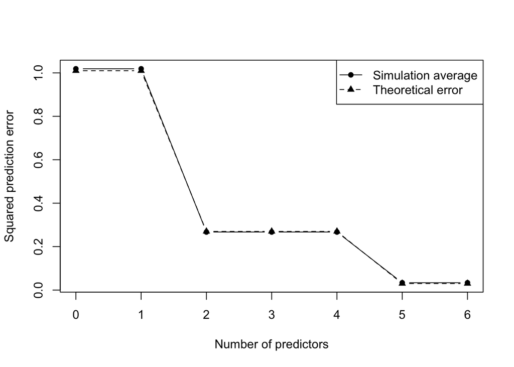

```r
plot(
  0:q,
  avg_error,
  type = "b",
  pch = 16,
  ylim = range(avg_error, theory_error),
  xlab = "Number of predictors",
  ylab = "Squared prediction error"
)

lines(
  0:q,
  theory_error,
  type = "b",
  pch = 17,
  lty = 2
)

legend(
  "topright",
  legend = c("Simulation average", "Theoretical error"),
  pch = c(16, 17),
  lty = c(1, 2)
)
```

**Show the starter code**

```r
best_j <- (0:q)[which.min(theory_error)]

best_j
```

```
[1] 5
```

3. All six regression coefficients are nonzero. Explain why only predictors 2 and 5 contribute directly to the mean response at $\mathbf x_0$. Contrast this target-specific error with the test MSE averaged over all rows of $\mathbf X_{\mathrm{all}}$ in Question 1.

Although all six coefficients are nonzero, a predictor contributes to the mean only when its value at the target point is nonzero. At the target point, only predictors 2 and 5 have value 1. The other predictors have value 0. Therefore, predictors 2 and 5 each contribute 0.5, and the mean response is 1. The error in this question is for only one target point. In contrast, the test MSE in Question 1 averages prediction errors over all 100 rows of the design matrix. Therefore, a predictor may have no direct effect at this target point but may still be important for prediction across the full data set. The best model for one target point may be different from the best model based on overall test MSE.

## Question 3: The optimism correction

Choose one candidate model before observing the response. Let $\mathbf X\in\mathbb R^{n\times p}$ be its full-rank design matrix, including the intercept, and let

$$\mathbf H
=\mathbf X
(\mathbf X^{\mathsf T}\mathbf X)^{-1}
\mathbf X^{\mathsf T}$$

be its hat matrix. Suppose

$$\mathbf y=\boldsymbol\mu+\boldsymbol\epsilon,
\qquad
\mathbf y^*=\boldsymbol\mu+\boldsymbol\epsilon^*,$$

Conditional on the fixed design $\mathbf X$, the two error vectors are independent, have mean zero, and have covariance matrix $\sigma^2\mathbf I_n$. Define

$$\operatorname{MSE}_{\mathrm{train}}
=
\frac{1}{n}
\left\lVert
\mathbf y-\mathbf H\mathbf y
\right\rVert_2^2,
\qquad
\operatorname{MSE}_{\mathrm{test}}
=
\frac{1}{n}
\left\lVert
\mathbf y^*-\mathbf H\mathbf y
\right\rVert_2^2.$$

The conditional bias vector of the fitted mean is

$$E(\mathbf H\mathbf y\mid\mathbf X)-\boldsymbol\mu
=
-(\mathbf I_n-\mathbf H)\boldsymbol\mu.$$

Let $B^2$ denote the **total squared approximation bias**:

$$B^2
=\left\lVert
(\mathbf I_n-\mathbf H)\boldsymbol\mu
\right\rVert_2^2.$$

Thus, $B^2/n$ is the mean squared approximation bias.

You may use

$$\mathbf H^{\mathsf T}=\mathbf H,
\qquad
\mathbf H^2=\mathbf H,
\qquad
\operatorname{tr}(\mathbf H)=p.$$

For any fixed matrix $\mathbf A$, you may also use

$$E\!\left(
\boldsymbol\epsilon^{\mathsf T}
\mathbf A
\boldsymbol\epsilon
\mid \mathbf X
\right)
=\sigma^2\operatorname{tr}(\mathbf A).$$

1. Derive

$$E(\operatorname{MSE}_{\mathrm{train}}\mid\mathbf X)
=\frac{B^2}{n}
+\sigma^2\left(1-\frac{p}{n}\right),$$

and

$$E(\operatorname{MSE}_{\mathrm{test}}\mid\mathbf X)
=\frac{B^2}{n}
+\sigma^2\left(1+\frac{p}{n}\right).$$

Let

$$\mathbf r=(\mathbf I_n-\mathbf H)\boldsymbol\mu,
\qquad
\|\mathbf r\|_2^2=B^2.$$

For training MSE,

$$\mathbf y-\mathbf H\mathbf y
=
\mathbf r+(\mathbf I_n-\mathbf H)\boldsymbol\epsilon.$$

Therefore,

$$\begin{aligned}
E(\mathrm{MSE}_{\mathrm{train}}\mid\mathbf X)
&=
\frac{1}{n}
\left[
B^2+\sigma^2\operatorname{tr}(\mathbf I_n-\mathbf H)
\right] \\
&=
\frac{B^2}{n}
+\sigma^2\left(1-\frac{p}{n}\right).
\end{aligned}$$

For test MSE,

$$\mathbf y^*-\mathbf H\mathbf y
=
\mathbf r+\boldsymbol\epsilon^*-\mathbf H\boldsymbol\epsilon.$$

Because the two errors are independent,

$$\begin{aligned}
E(\mathrm{MSE}_{\mathrm{test}}\mid\mathbf X)
&=
\frac{1}{n}
\left[
B^2+n\sigma^2+p\sigma^2
\right] \\
&=
\frac{B^2}{n}
+\sigma^2\left(1+\frac{p}{n}\right).
\end{aligned}$$

2. Deduce the expected optimism, defined as $E(\operatorname{MSE}_{\mathrm{test}}-\operatorname{MSE}_{\mathrm{train}}\mid\mathbf X)$. For

$$n=120,
\qquad
p=5,
\qquad
\frac{B^2}{n}=0.04,
\qquad
\sigma^2=1,$$

calculate the expected training MSE, expected test MSE, and their difference. Explain why the ordering need not hold for every realized pair of responses.

The expected optimism is

$$E(\mathrm{MSE}_{\mathrm{test}}-\mathrm{MSE}_{\mathrm{train}}\mid \mathbf X)
=
\frac{2\sigma^2p}{n}.$$

For $n=120$, $p=5$, $\frac{B^2}{n}=0.04$, and $\sigma^2=1$,

$$E(\mathrm{MSE}_{\mathrm{train}}\mid\mathbf X)
=
0.04+1\left(1-\frac{5}{120}\right)
=
0.9983.$$

$$E(\mathrm{MSE}_{\mathrm{test}}\mid\mathbf X)
=
0.04+1\left(1+\frac{5}{120}\right)
=
1.0817.$$

Therefore,

$$1.0817-0.9983=0.0833.$$

The expected test MSE is larger than the expected training MSE. However, for one realized pair of responses, random noise may make the test MSE smaller than the training MSE.

3. Continue with $n=120$ and $p=5$. Suppose the candidate model has residual sum of squares $\operatorname{RSS}=116.4$, and suppose a common estimate of the error variance is $\widehat\sigma^2=0.96$.

Calculate

$$\widehat{\operatorname{MSE}}_{\mathrm{test}}
=\frac{
\operatorname{RSS}+2p\widehat\sigma^2
}{n},$$

and

$$C_p
=\frac{\operatorname{RSS}}{\widehat\sigma^2}
-n+2p.$$

Show how these two quantities are related, and explain why minimizing $C_p$ is equivalent to minimizing the corrected test MSE when $n$ and $\widehat\sigma^2$ are common to all candidate models.

The corrected test MSE is

$$\widehat{\mathrm{MSE}}_{\mathrm{test}}
=
\frac{116.4+2(5)(0.96)}{120}
=
1.05.$$

Mallows’ $C_p$ is

$$C_p
=
\frac{116.4}{0.96}-120+2(5)
=
11.25.$$

Their relationship is

$$\widehat{\mathrm{MSE}}_{\mathrm{test}}
=
\widehat{\sigma}^2
+
\frac{\widehat{\sigma}^2}{n}C_p.$$

When $n$ and $\widehat{\sigma}^2$ are the same for all models, minimizing $C_p$ also minimizes the corrected test MSE.

## Question 4: Comparing Mallows’ $C_p$, AIC, and BIC

Use `data/diabetes.csv`, with `y` as the response. Use rows 1 through 370 as the training data, and let $n=370$ denote the training sample size. Do not use rows 371 through 442 in this question. Fit the following ordinary least-squares models, each with an intercept.

| Model | Predictors | $p$ |
| --- | --- | --- |
| Model A | `bmi`, `bp`, `s5`, `sex`, `s1`, `s2`, `s4` | 8 |
| Model B | all predictors in Model A, followed by `s6` | 9 |
| Full reference | all ten predictors | 11 |

Here $p$ counts fitted mean parameters, including the intercept. Estimate one common noise variance from the full reference model:

$$\widehat\sigma^2_{\mathrm{full}}
=\frac{\operatorname{RSS}_{\mathrm{full}}}{n-11}.$$

For Models A and B, calculate

$$C_p
=\frac{\operatorname{RSS}}{\widehat\sigma^2_{\mathrm{full}}}
-n+2p,$$

$$\operatorname{AIC}^{\mathrm{red}}
=n\log\left(\frac{\operatorname{RSS}}{n}\right)+2p,$$

and

$$\operatorname{BIC}^{\mathrm{red}}
=n\log\left(\frac{\operatorname{RSS}}{n}\right)
+p\log(n).$$

The reduced AIC and BIC omit constants shared by the two candidate models. Smaller values are preferred within each criterion.

1. Fit the three models. Report $p$, RSS, the residual degrees of freedom of the full model, and $\widehat\sigma^2_{\mathrm{full}}$.

**Show the starter code**

```r
diabetes <- read.csv("data/diabetes.csv")

train <- diabetes[1:370, ]

model_A <- lm(y ~ bmi + bp + s5 + sex + s1 + s2 + s4,
              data = train)

model_B <- lm(y ~ bmi + bp + s5 + sex + s1 + s2 + s4 + s6,
              data = train)

model_full <- lm(y ~ age + sex + bmi + bp + s1 + s2 +
                   s3 + s4 + s5 + s6,
                 data = train)

p_A <- length(coef(model_A))
p_B <- length(coef(model_B))
p_full <- length(coef(model_full))

RSS_A <- sum(resid(model_A)^2)
RSS_B <- sum(resid(model_B)^2)
RSS_full <- sum(resid(model_full)^2)

df_full <- df.residual(model_full)
sigma2_full <- RSS_full / df_full

data.frame(
  Model = c("A", "B", "Full"),
  p = c(p_A, p_B, p_full),
  RSS = c(RSS_A, RSS_B, RSS_full)
)
```

```
  Model  p     RSS
1     A  8 1098909
2     B  9 1089717
3  Full 11 1089452
```

**Show the starter code**

```r
df_full
```

```
[1] 359
```

**Show the starter code**

```r
sigma2_full
```

```
[1] 3034.684
```

Model A has 8 parameters, Model B has 9 parameters, and the full model has 11 parameters. The full model has 359 residual degrees of freedom, and its estimated error variance is about 3034.68.

2. Calculate $C_p$, reduced AIC, and reduced BIC for Models A and B. State which model each criterion selects. Do not compare numerical values across different criteria.

**Show the starter code**

```r
n_train <- nrow(train)

RSS <- c(RSS_A, RSS_B)
p <- c(p_A, p_B)

Cp <- RSS / sigma2_full - n_train + 2 * p
AIC_red <- n_train * log(RSS / n_train) + 2 * p
BIC_red <- n_train * log(RSS / n_train) + p * log(n_train)

results_b <- data.frame(
  Model = c("A", "B"),
  Cp  = round(Cp, 3),
  AIC = round(AIC_red, 3),
  BIC = round(BIC_red, 3)
)

results_b
```

```
  Model    Cp      AIC      BIC
1     A 8.116 2974.640 3005.948
2     B 7.087 2973.532 3008.754
```

Mallows’ Cp selects Model B because it has the smaller Cp. Reduced AIC also selects Model B. Reduced BIC selects Model A. The values are compared only within each criterion.

3. Compare the improvement in fit from adding `s6` with the one-parameter penalty under each criterion. Use this comparison to explain any disagreement. Why does selecting a model not establish that it is the true data-generating model?

Adding `s6` reduces the RSS by

$$1098908.6-1089717.1=9191.5.$$

For Mallows’ $C_p$, the improvement is

$$\frac{9191.5}{3034.68}=3.03,$$

which is larger than the penalty of 2. Therefore, $C_p$ selects Model B.

For AIC, the improvement is

$$370\log\left(\frac{1098908.6}{1089717.1}\right)=3.11,$$

which is also larger than the penalty of 2. Therefore, AIC selects Model B.

For BIC, the penalty is

$$\log(370)=5.91.$$

Since 3.11 is smaller than 5.91, BIC selects Model A. The disagreement occurs because BIC gives a stronger penalty for adding predictors.

Selecting a model only shows that it is preferred among the candidate models under a particular criterion. It does not prove that the model is the true data-generating model because the data contain random noise, and the true model may not be among the candidate models.

## Question 5: Validation and final test data

Use rows 1 through 370 of `diabetes.csv` as the training data and rows 371 through 442 as the final test data. Consider eleven nested candidate models. For $j=0,1,\ldots,10$, the model with $j$ predictors contains an intercept and the first $j$ predictors in this order:

`age`, `sex`, `bmi`, `bp`, `s1`, `s2`, `s3`, `s4`, `s5`, `s6`.

An analyst proposes the following procedure:

1. Fit all eleven candidate models using the training data.
2. Calculate the MSE of each model on the final test data.
3. Select the model with the smallest test MSE.
4. Report that minimum as the final estimate of prediction error.

The analyst argues that the procedure is valid because the final test data were not used to estimate the regression coefficients.

1. Identify the first step that misuses the final test data. Explain why the minimum of eleven test MSE values is generally too favorable as an estimate of the selected procedure’s future prediction error.

The first misuse occurs in Step 3, when the final test data are used to select the model with the smallest test MSE. The test data are therefore no longer independent of model selection.

Each test MSE contains random variation. By choosing the smallest value among eleven models, we may select a model that was unusually lucky on this test set. Therefore, the minimum test MSE is usually too small and underestimates the model’s future prediction error. Step 4 then reports an overly optimistic result.

2. Rewrite the analysis using five-fold cross-validation within the training data. State how the predictor count is selected, what is refitted, and when the final test data may be used.

Split the 370 training observations into five folds. For each predictor count from 0 to 10, fit the model using four folds and calculate the MSE on the remaining fold. Repeat this for all five folds and calculate the average validation MSE.

Select the predictor count with the smallest average validation MSE. Then refit that model using all 370 training observations. Finally, use the untouched final test data once to calculate and report the final test MSE.

3. Suppose the analyst has already examined all eleven test MSE values. What can still be reported transparently, and what additional data would be needed for a new final evaluation?

The analyst can report all eleven test MSE values and clearly state that the test data were used to select the model. The smallest test MSE can be reported as an exploratory result, but not as an unbiased estimate of future prediction error.

A new independent test data set, not used for model selection or fitting, is needed for a valid final evaluation.

## Reference

James, Witten, Hastie, Tibshirani, and Taylor, [*An Introduction to Statistical Learning*](https://www.statlearning.com/), Chapters 3, 5, and 6.